# Homework:Bootstrap

Carlos Rodriguez

11/12/2017

Homework:ANOVA 1 A description of the data – the variables, the origin of the data and the data set (such that I could find it and replicate your work).

The data used is the CO2 uptake in grass plants from an experiment on the cold tolereance of grass species Echinochloa crus-galli. The data includes the plant id along with the type, which is the orgin such as Quebec or Mississippi. The treatment which was either chilled or nonchilled. The carbon dioxide concentrations in mL/L and the uptake which is the carbon dioxide uptake rates in umol/m^2 sec.

2. An appropriate plot to display the data with respect to your analysis.

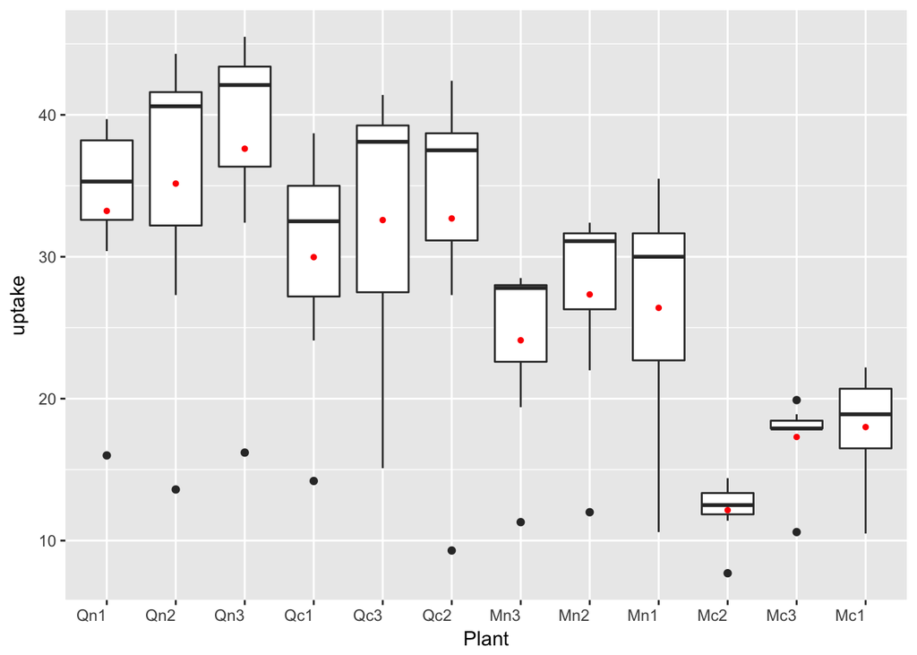

```r
library(ggplot2)
p <- ggplot(CO2, aes(Plant, uptake)) + geom_boxplot() + stat_summary(fun.y=mean, colour="red",geom="point", size=1) + theme(axis.text.x=element_text(angle=0, hjust=1))
p
```

3. A statement about the validity of ANOVA via its assumptions, or a statement why you’re not concerned about breaking one of the assumptions.

The validity of this data seems to be reasonable considering the fact that the variance within the groups or plant type are closely related related for the most part. A few exceptions with plant Mc3 where the variability is small and will be taken out from the data along with plant Mc2 and Mc1.

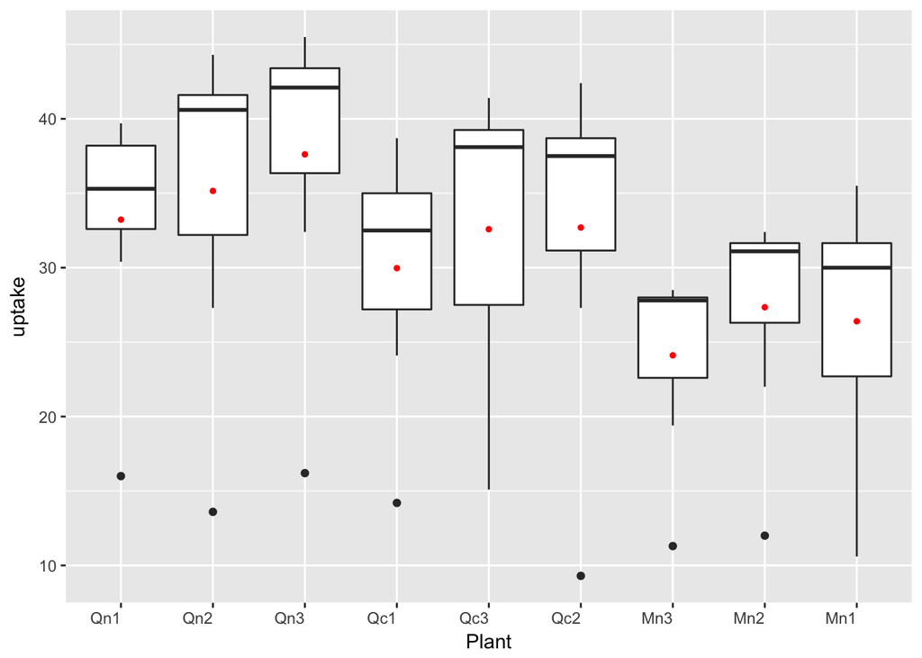

```r
library(ggplot2)
q <- CO2
plantremove <- c("Mc2","Mc1","Mc3")
q2 <- q[ ! q$Plant %in% plantremove, ]
pq <- ggplot(q2, aes(Plant, uptake)) + geom_boxplot() + stat_summary(fun.y=mean, colour="red",geom="point", size=1) + theme(axis.text.x=element_text(angle=0, hjust=1))
pq
```

4. A formal hypothesis.

The mean CO2 upatake of plants from the species Echinochloa crus-galli vaaries by location and treatment.

H0: µQn1 = µQn2 = µQn3 = …= µMn1

H1: at least one of the mean CO2 uptake is different.

```r
plantremove <- c("Mc2","Mc1","Mc3")
q2 <- q[ ! q$Plant %in% plantremove, ]
q2$Plant <- factor(q2$Plant)
#q2 <- factor( q2$Plant , ordered = FALSE )
reg = lm(uptake~ Plant, data=q2,contrasts = sum)
modelplant <- lm(formula=uptake~ factor(Plant), data=q2)
summary(modelplant)
```

```
##
## Call:
## lm(formula = uptake ~ factor(Plant), data = q2)
##
## Residuals:
##     Min      1Q  Median      3Q     Max
## -23.400  -4.964   3.757   5.707   9.700
##
## Coefficients:
##                 Estimate Std. Error t value Pr(>|t|)
## (Intercept)      31.0127     1.1702  26.502   <2e-16 ***
## factor(Plant).L  -9.6861     3.5106  -2.759   0.0079 **
## factor(Plant).Q  -1.9726     3.5106  -0.562   0.5765
## factor(Plant).C   3.4974     3.5106   0.996   0.3236
## factor(Plant)^4  -0.1370     3.5106  -0.039   0.9690
## factor(Plant)^5   1.3498     3.5106   0.384   0.7021
## factor(Plant)^6  -1.2360     3.5106  -0.352   0.7261
## factor(Plant)^7  -6.3890     3.5106  -1.820   0.0743 .
## factor(Plant)^8   0.5238     3.5106   0.149   0.8819
## ---
## Signif. codes:  0 '***' 0.001 '**' 0.01 '*' 0.05 '.' 0.1 ' ' 1
##
## Residual standard error: 9.288 on 54 degrees of freedom
## Multiple R-squared:  0.1883, Adjusted R-squared:  0.06807
## F-statistic: 1.566 on 8 and 54 DF,  p-value: 0.157
```

```r
##anova(modelplant)
is.factor(q2[,"Plant"])
```

```
## [1] TRUE
```

5. A formal conclusion in both Statistics and in English.

Our p value turned out to be >0.05 so we can’t reject the null hypthesis. In other words, there is not sufficent evidence to be able to claim that the mean CO2 uptake of the plants varies from location and treatment.

1. Start from your work in HW ANOVA.
1. Calculate the fitted/predicted values of your ANOVA model. Explain, in one sentence, why there are so many of the same values

```r
yhat <- fitted(modelplant)
yhat
```

```
##        1        2        3        4        5        6        7        8
## 33.22857 33.22857 33.22857 33.22857 33.22857 33.22857 33.22857 35.15714
##        9       10       11       12       13       14       15       16
## 35.15714 35.15714 35.15714 35.15714 35.15714 35.15714 37.61429 37.61429
##       17       18       19       20       21       22       23       24
## 37.61429 37.61429 37.61429 37.61429 37.61429 29.97143 29.97143 29.97143
##       25       26       27       28       29       30       31       32
## 29.97143 29.97143 29.97143 29.97143 32.70000 32.70000 32.70000 32.70000
##       33       34       35       36       37       38       39       40
## 32.70000 32.70000 32.70000 32.58571 32.58571 32.58571 32.58571 32.58571
##       41       42       43       44       45       46       47       48
## 32.58571 32.58571 26.40000 26.40000 26.40000 26.40000 26.40000 26.40000
##       49       50       51       52       53       54       55       56
## 26.40000 27.34286 27.34286 27.34286 27.34286 27.34286 27.34286 27.34286
##       57       58       59       60       61       62       63
## 24.11429 24.11429 24.11429 24.11429 24.11429 24.11429 24.11429
```

There are so many of the same values because they belong to a common group and it shows the mean for the whole group.

2. Calculate the coefficients from your model. Explain what the intercept is and you find another level’s group mean.

```r
coefficients(modelplant)
```

```
##     (Intercept) factor(Plant).L factor(Plant).Q factor(Plant).C
##      31.0126984      -9.6861469      -1.9726033       3.4973916
## factor(Plant)^4 factor(Plant)^5 factor(Plant)^6 factor(Plant)^7
##      -0.1369706       1.3497705      -1.2360331      -6.3889518
## factor(Plant)^8
##       0.5238489
```

```r
#plantcof
```

```r
plantinter <- 31.0126984
plantinter+3.4973916
```

```
## [1] 34.51009
```

3. Calculate the residuals for your model. Pick a negative one and pick a positive one, explain what the sign of each means.

```r
resid<-residuals(modelplant)
resid
```

```
##           1           2           3           4           5           6
## -17.2285714  -2.8285714   1.5714286   3.9714286   2.0714286   5.9714286
##           7           8           9          10          11          12
##   6.4714286 -21.5571429  -7.8571429   1.9428571   6.6428571   5.4428571
##          13          14          15          16          17          18
##   6.2428571   9.1428571 -21.4142857  -5.2142857   2.6857143   4.4857143
##          19          20          21          22          23          24
##   5.2857143   6.2857143   7.8857143 -15.7714286  -5.8714286   0.3285714
##          25          26          27          28          29          30
##   4.6285714   2.5285714   5.4285714   8.7285714 -23.4000000  -5.4000000
##          31          32          33          34          35          36
##   2.3000000   6.1000000   5.9000000   4.8000000   9.7000000 -17.4857143
##          37          38          39          40          41          42
## -11.5857143   5.5142857   1.4142857   6.3142857   7.0142857   8.8142857
##          43          44          45          46          47          48
## -15.8000000  -7.2000000  -0.2000000   3.6000000   4.5000000   6.0000000
##          49          50          51          52          53          54
##   9.1000000 -15.3428571  -5.3428571   3.2571429   4.4571429   5.0571429
##          55          56          57          58          59          60
##   3.7571429   4.1571429 -12.8142857  -4.7142857   1.6857143   3.7857143
##          61          62          63
##   4.3857143   3.9857143   3.6857143
```

```r
plantinter+(-17.2285714)
```

```
## [1] 13.78413
```

```r
plantinter+1.5714286
```

```
## [1] 32.58413
```

2. Calculate a 98% bootstrapped confidence interval for the difference between two independent (not paired) means, using variables I have not previously used. Provide a complete analysis including at least:
1. A description of the data – the variables, the origin of the data and the data set (such that I could find it and replicate your work).

The data below is the effectiveness of insect sprays. There are 6 different sprays used with the number count of effectiveness on insects. It was narrowed to display only the mean of two sprays.This data is from the library datasets called InsectSprays.

2. An appropriate plot to display the data with respect to your analysis.

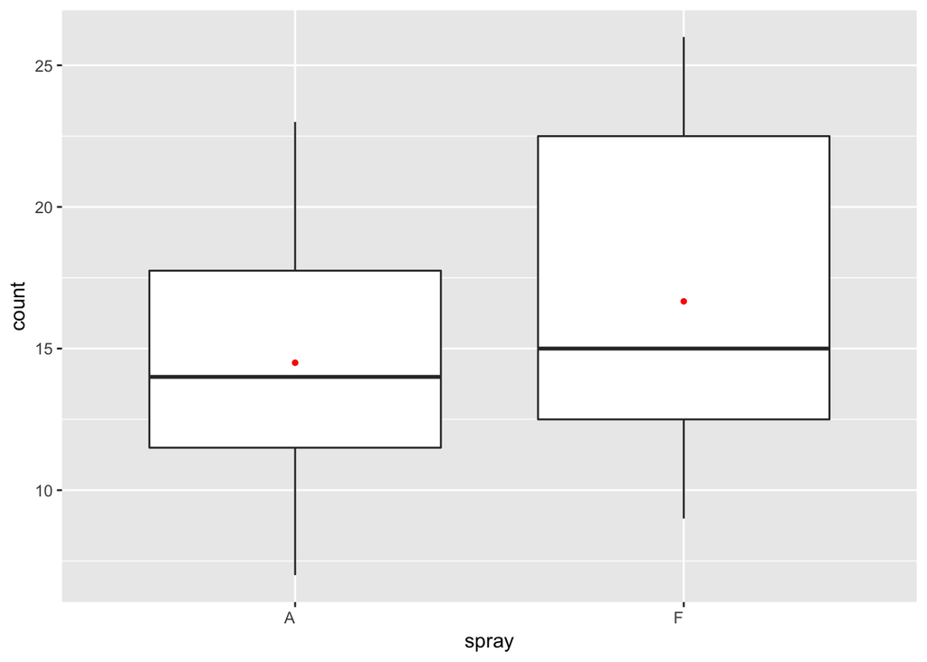

```r
library(datasets)
data(InsectSprays)
library(ggplot2)
insectremove <- c("B","C","D","E")
inspray <- InsectSprays[ ! InsectSprays$spray %in% insectremove, ]
InSp <- ggplot(inspray, aes(spray, count)) + geom_boxplot() + stat_summary(fun.y=mean, colour="red", geom="point", size=1) + theme(axis.text.x=element_text(angle=0, hjust=1))
InSp
```

```r
t.test(count~spray, data=inspray, conf=0.98)
```

```
##
##  Welch Two Sample t-test
##
## data:  count by spray
## t = -0.96194, df = 20.523, p-value = 0.3473
## alternative hypothesis: true difference in means is not equal to 0
## 98 percent confidence interval:
##  -7.848175  3.514841
## sample estimates:
## mean in group A mean in group F
##        14.50000        16.66667
```

```r
library(dplyr)
library(magrittr)
library(boot)
diff_medians <- function(data, i) {
data[i,] %>%
group_by(spray) %>%
summarise(m=median(count)) %>%
.[['m']] %>%
diff %>%
`*`(-1)
}

b <- inspray %>%
  select(count, spray) %>%
  na.omit %>%
  boot(., statistic=diff_medians, R=4000, parallel="multicore", ncpus=3)
bCI <- boot.ci(b, conf=0.98, type="bca")
bCI
```

```
## BOOTSTRAP CONFIDENCE INTERVAL CALCULATIONS
## Based on 4000 bootstrap replicates
##
## CALL :
## boot.ci(boot.out = b, conf = 0.98, type = "bca")
##
## Intervals :
## Level       BCa
## 98%   (-12,   4 )
## Calculations and Intervals on Original Scale
```